# Assignment 4 - Group 4

true

```r
library(tidyverse)
library(dplyr)
library(kableExtra)
library(bookdown)
```

```r
dat = read.csv("Data/IMDb movies.csv")
glimpse(dat)
```

```
## Rows: 81,273
## Columns: 22
## $ imdb_title_id         <chr> "tt0000574", "tt0001892", "tt0002101", "tt000...
## $ title                 <chr> "The Story of the Kelly Gang", "Den sorte drÃ...
## $ original_title        <chr> "The Story of the Kelly Gang", "Den sorte drÃ...
## $ year                  <int> 1906, 1911, 1912, 1911, 1912, 1919, 1913, 191...
## $ date_published        <chr> "1906-12-26", "1911-08-19", "1912-11-13", "19...
## $ genre                 <chr> "Biography, Crime, Drama", "Drama", "Drama, H...
## $ duration              <int> 70, 53, 100, 68, 60, 85, 120, 120, 55, 121, 5...
## $ country               <chr> "Australia", "Germany, Denmark", "USA", "Ital...
## $ language              <chr> "", "", "English", "Italian", "English", "Ger...
## $ director              <chr> "Charles Tait", "Urban Gad", "Charles L. Gask...
## $ writer                <chr> "Charles Tait", "Urban Gad, Gebhard SchÃ¤tzle...
## $ production_company    <chr> "J. and N. Tait", "Fotorama", "Helen Gardner ...
## $ actors                <chr> "Elizabeth Tait, John Tait, Norman Campbell, ...
## $ description           <chr> "True story of notorious Australian outlaw Ne...
## $ avg_vote              <dbl> 6.1, 5.9, 5.2, 7.0, 5.7, 6.8, 6.2, 6.7, 5.5, ...
## $ votes                 <int> 537, 171, 420, 2019, 438, 709, 241, 187, 211,...
## $ budget                <chr> "$ 2250", "", "$ 45000", "", "", "", "ITL 450...
## $ usa_gross_income      <chr> "", "", "", "", "", "", "", "", "", "", "", "...
## $ worlwide_gross_income <chr> "", "", "", "", "", "", "", "", "", "", "", "...
## $ metascore             <dbl> NA, NA, NA, NA, NA, NA, NA, NA, NA, NA, NA, N...
## $ reviews_from_users    <dbl> 7, 4, 24, 28, 12, 11, 6, 3, 7, 9, 9, 16, 8, 2...
## $ reviews_from_critics  <dbl> 7, 2, 3, 14, 5, 9, 4, 1, 1, 9, 29, 7, 22, 2, ...
```

```r
dat %>%
        dplyr::select(metascore) %>%
        summary() %>%
        kable(caption = "Metascore summary") %>%
        kable_styling(bootstrap_options = c("striped", "hover"))
```

[output not shown]

# 5513 - Assignment 4

Aryan Jain

## Director Analysis

#### Most Successful Director

Lets take a look at the some of most successful directors from our dataset. Now, there are limitless ways to measure success but for our test, we’re only looking at people with at least 4 movies under their belt and a Metascore upwards of 80. And conveniently, we get only 10 names.

[output not shown]

According to IMDb, metascore is a single number that represents the overall critical opinion about a movie. Its legitimacy is derived from applying a weighted average to the reviews of the world’s most respected critics. That said, metascore is still an extremely vague concept - particularly when it comes to the threshold of what metascore can be considered good.

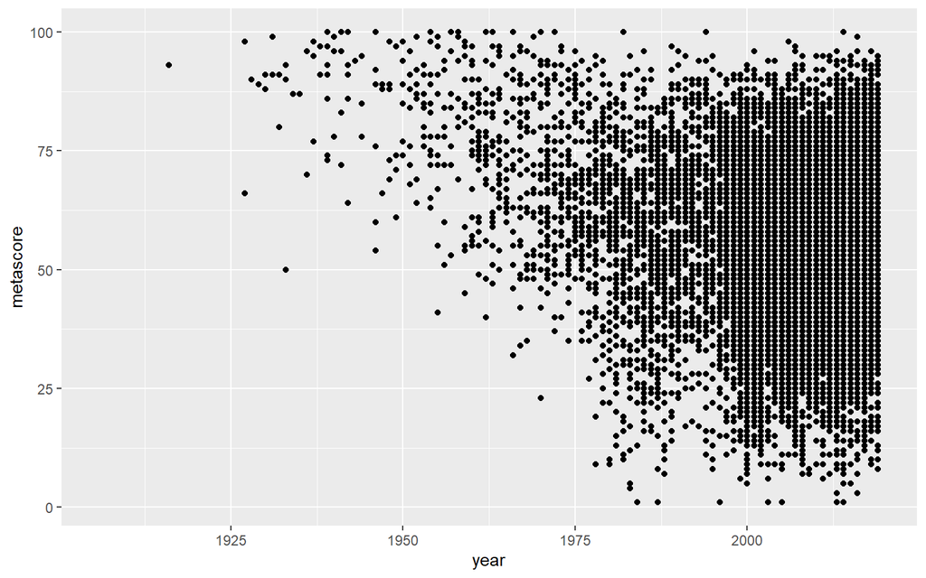

Figure 0.1: metascore vs time

```r
f1wn = dat %>%
             ggplot(aes(x = year, y = metascore)) +
             geom_point()
f1wn
```

```r
dat2wn <- dat %>%
               dplyr::select(title,
                             year,
                             metascore)

dat3wn <- dat2wn %>%
                arrange(-metascore)

dat3wn %>%
        head(20) %>%
        kable(caption = "The top 20 movies arranged by metascore") %>%
        kable_styling(bootstrap_options = c("striped", "hover"))
```

Table 0.2: The top 20 movies arranged by metascore

title

We get some interesting results, as on one hand there is Mike Leigh with as much as 13 movies but a lower average metascore. On the other hand, there are directors like Damien Chazelle and Patrick wang with 4 movies each and an average metascore of 87 and 86 respectively.

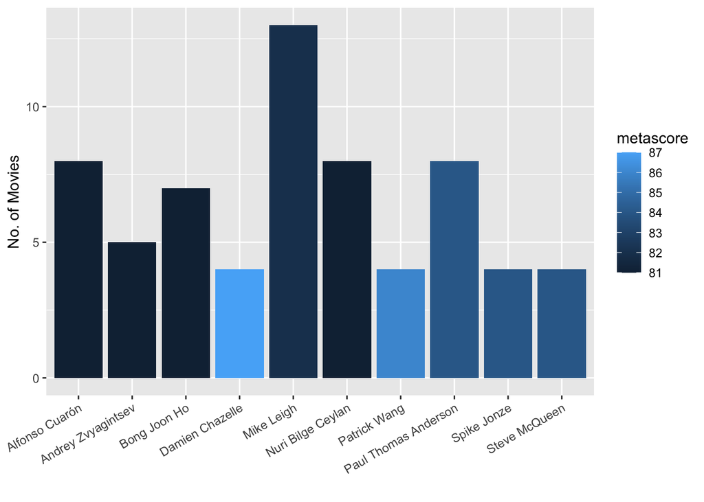

#### Top Grossing Movie

[output not shown]

It can be observed that the Alfonso Cuarón is the director of the top grossing movie **Harry Potter and the Prisoner of Azkaban** which made $796,093,802 worldwide. Followed by, Damien Chazelle, the director of **La La Land** grossing $446,092,35. Suprisingly, Patrick Wang, with an average metascore of 86 and a total of 4 movies made the least at just $101,934.

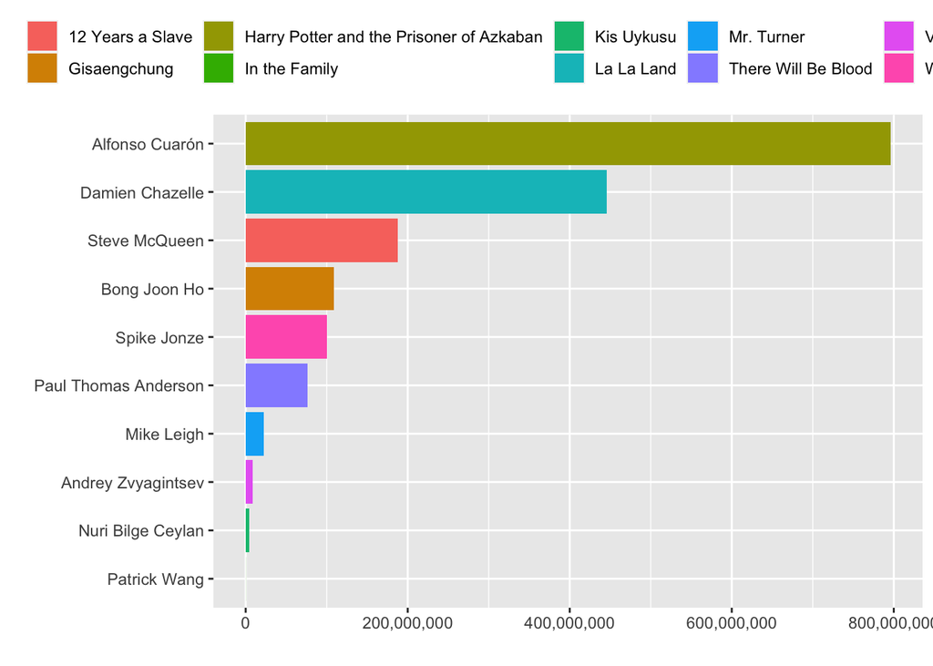

## Movie Length and Language Analysis

Let’s look at some of the common movie languages.

[output not shown]

From the above table, it is quite clear that most movies are released in either only english or in multi-lingual format.

#### Is there a pattern in Movie length for various languages.

[output not shown]

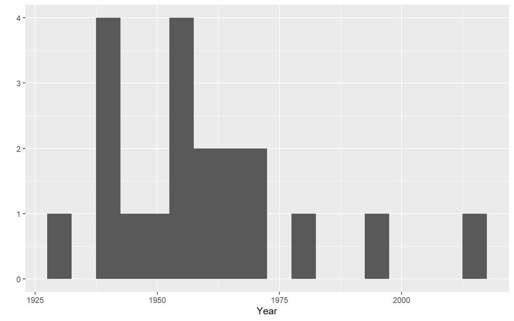

Figure 0.2: Time distribution of top twenty movies

```r
dat3wn %>%
        head(20) %>%
        ggplot(aes(year)) +
        geom_histogram(binwidth = 5) +
        xlab("Year") +
        ylab("")
```

Assuming that metascore is a reliable representation of a movie’s quality, it is easy to see why arguments have been made that movies produced in recent times are not as good. Contrarily, a counterargument can be made that there were just as many bad movies made during previous generations that have been forgotten or overshadowed by the classics. Due to the clear bias within this dataset, it is still unclear which argument is stronger.

# 1 Citations

dplyr @dplyr

kableExtra @kableExtra

bookdown @bookdown

[figure not shown]

From the plot above, we can infer that Hindi movies are usually much longer than other languages clocking at an average runtime of 140 minutes. While, english movies are usually the shortest at just 93 minutes.